# NCbirths Analysis

Matt Robinson, Athena Higgins, Ethan Sennett, Peter Nguyen

12/7/2016

# 1. Group Analysis

## Project Overview

For our final project, based on the NCbirths dataset, we will explore factors related to childbirth data at a particular hospital. The NCbirths dataset includes the following variables, which will be useful in exploring the stories contained within this dataset.

| **Variable** | **Explanation** |
| --- | --- |
| MomAge | The mothers age. |
| Marital | The marital status of the mother. 1 = married, 2 = not married. |
| RaceMom | Mother’s race: 1=white, 2=black, 3=American Indian, 4=Chinese, |
|  | 5=Japanese, 6=Hawaiian, 7=Filipino, 8=Other Asian or Pacific Islander |
| Gained | The amount of weight gained during pregnancy (in pounds). |
| BirthWeightOz | The birth weight of the child (in ounces). |
| Weeks | The number of completed weeks of gestation. |
| Plural | Multiple birth indicator. 1=single birth, 2=twins, 3=triplets. |

Examining relationships among these factors provides insight into the complexity of pregnancy for women and their infants, and the plethora of variables which influence childbirth. Some interesting relationships and interactions that we will explore in this report include:

1. The relationship between the mothers marital status, race and age.
2. The relationship between the mothers marital status, weight gained during pregnancy and age.
3. The relationship between the mothers marital status, the childs weight at birth and number of weeks of gestation.
4. The relationship between the mothers marital status, the childs weight at birth and whether or not the child was a twin or triplet.

Analyzing the data, through lenses shaped by these factors, allows us to tell intriguing social and biological stories about women’s individual pregnancy experiences. Each individual analysis of the dataset incorporates marital status as a categorical factor, in order to provide some consistency throughout analysis, and to allow for comprehensive overview of marital influence on pregnancy and childbirth.

We will use our analysis to prove or disprove the following hypotheses regarding marital status and pregnancy:

1. Hypothesis 1 - Births involving a single mother will exhibit a higher weight gained during pregnancy, a lower average of weeks of gestation and a lower average child weight at birth.
2. Hypothesis / Exploration 2- Interpreting data related to marital status, race, and age will allow for an intriguing discussion of social factors related to childbirth, and insight into the influence of these factors on pregnancy. Marital status and race are not biological factors, and thus should have no physical influence on childbirth. When different patterns emerge in the childbirth data, with respect to these variables, trends could indicate the influence of social pressures and climate on childbirth.
3. Hypothesis 3 - Births involving a married mother where the child will have a higher average birth weight, and will be a twin. On average, a married family will have a higher income than someone who is not married. When this is taken into account, food intake for the family is affected so by being married, the mother will be able to eat more and in turn the children will have a higher birth weight.

## Missing Data

Using R, we were able to find 41 observations where at least 1 variable had missing data. We decided to discard all 41 observations, because eliminating these entries would not remove an extensive amount of data from the entire collection of data. We also examined the individual entries missing data, and concluded that there was not common trend among participants for whom information was missing. (If there had been a trend- for example, if all Japanese mothers neglected to provide their marital status, then removing data could have posed a problem when analyzing the data.) All of the visualizations and analysis conducted for this paper utalize the “clean” / “complete” dataset.

## Visualization of Data

The plots below provide some basic visualiazations of the data collected, to gain some familiarity with the dataset.

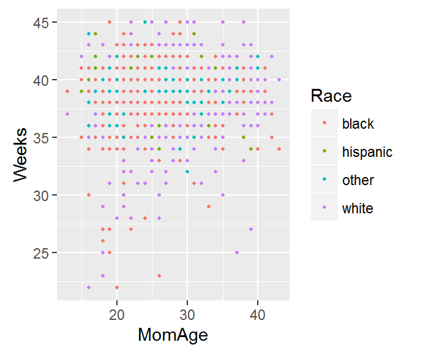

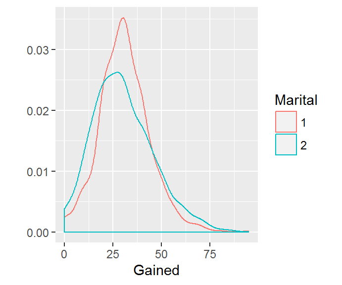

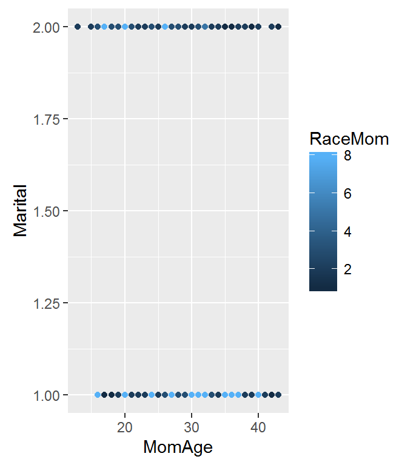

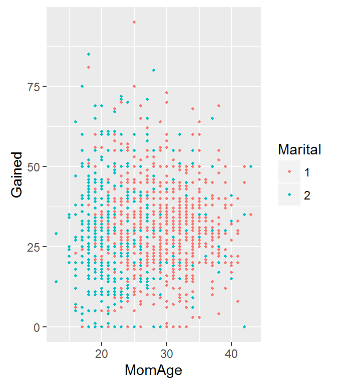

# 2. Individual Analyses

## Variables to Consider: Marital Status, RaceMom, MomAge

Note: RaceMom 1=white, 2=black, 3=American Indian, 4=Chinese, 5=Japanese, 6=Hawaiian, 7=Filipino, or 8=Other

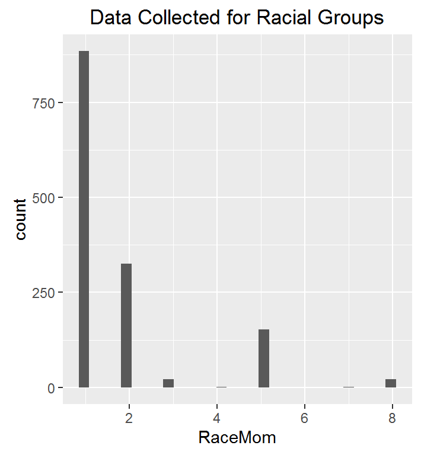

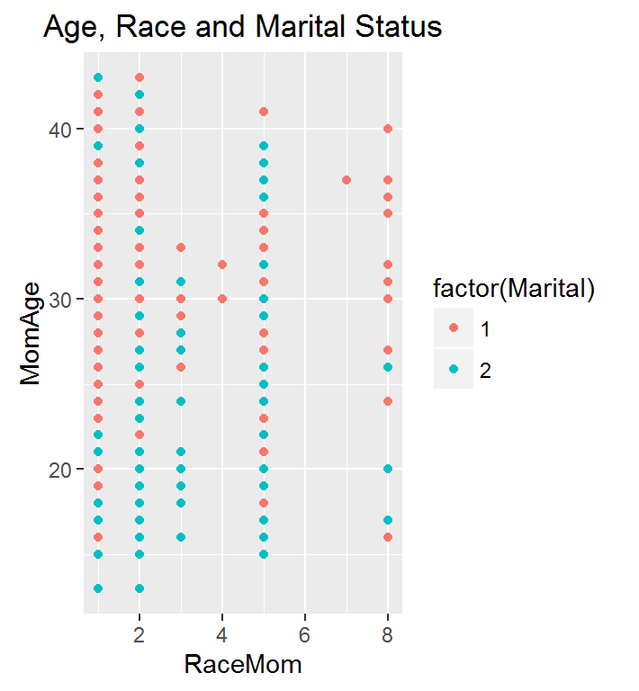

Notes: This graphic illustrates the pitfalls of conducting a convenience sample. The groups represented clearly neglect certain subsets of the population (for example, the hawaiian individuals are not represented in the dataset). There is one data point for the Filipino race- this means that the entire set of statistics computed for the Filipino subset is based on one individual. It is important to keep this oversimplification in mind when interpreting any statistics computed

It is also fascinating to examine this distribution after it has been factored by marital status. We can dive into this exploration further, by comparing the mean MomAge value computed for different subsets within the population.

The following are mean age values for new mothers, categorized by their race.

Mean Values Computed:

| **Race* * | **Mean MomAge** |
| --- | --- |
| population | 26.76 |
| white | 27.92 |
| black | 24.53 |
| american indian | 24.09 |
| chinese | 31.0 |
| japanese | 24.75 |
| hawaiian | NaN |
| filipino | 37 |
| other | 28.86 |

I also applied several t-tests of the data, in order to evaluate whether the difference in means for subsets of the populations is statistically significant. These computations allow for extraction of a pvalue (pvalue gives the probability of obtaining a result equal to / more extreme than the outcome observed, under the the assumption that the null hypothesis is true.) The Ttest null hypothesis states that the difference in mean values is not statistically significant. However, if the pvalue is very small (less than alpha), we can reject the null hypothesis, and conclude that the difference in mean values is statistically significant.

TTest P-Values

Difference in mom age- comparing specific racial groups to the entire population

| **Race** | **Pvalue** | **Significance** |
| --- | --- | --- |
| white | 4.730464e-06 | Reject the null- statistically significant difference |
| black | 1.486671e-09 | Reject the null- statistically significant difference |
| american indian | 0.03067128 | Depending on alpha, statistically significant difference |
| chinese | NaN |  |
| japanese | 1.335714e-05 | Reject the null- statistically significant difference |
| hawaiian | NaN |  |
| filipino | NaN |  |
| other | 0.1550142 | Fail to reject |
| white vs. black | 4.78133e-18 | Reject the null- statistically significant difference |

Other types of T-tests

This TTest determines if there is a statistically significant difference in MomAge between different racial groups. When comparing white and black mothers, the p-value computed (4.78133e-18) prompts us to reject the null hypothesis, and conclude that there is a statistically significant difference in ages.

We can also execute T-Tests comparing MomAge between married and non-married women. This computation can take place after extracting a particular subset of the data (for example, the subset of white individuals). This allows for further insight into the overall dataset.

T-Tests, Comparing MomAge between married and non-married women (factored by race)

| **Race** | **Pvalue** | **Significance** |
| --- | --- | --- |
| white | 4.003403e-30 | Reject the null- statistically significant difference |
| black | 4.793121e-18 | Reject the null- statistically significant difference |
| american indian | 3.040416e-05 | Reject the null- statistically significant difference |
| chinese | NaN |  |
| japanese | 0.05769045 | Fail to Reject |
| hawaiian | NaN |  |
| filipino | NaN |  |
| other | 0.0001803798 | Reject the null- statistically significant difference |
| Population | 2.929577e-72 |  |

The pvalues computed, and the conclusions we draw from these pvalues, provide interesting insight into the dataset. For example, the japanese subset is the only population for which the age of married vs. not-married mothers is not statistically significant. The power of the T-Test lies in its ability to make sense of large datasets, and to determine which differences are meaningful (as opposed to natural variation which exists within the population).

Another powerful story emerges when we build a regression model to predict MomAge from MomRace and Marital Status. This regression is based on the concept of variable interaction (that MomRace and Marital interact in unique ways, to influence predictions made of MomAge). The regression will result in B values for each possible combination (example- white married, white not married, black married, black not married…). The regression attempts to model (MomAge - Population_mean_age), the difference between MomAge for a specific subset, and the overall average population age. This regression does not require an intercept (because it is categorical, not continuous data), hence the -1 term.

Coefficients Observed

| **Subset** | **Coefficient** | **Notes** |
| --- | --- | --- |
| white married | 2.4118 |  |
| white not married | -6.2118 |  |
| black married | 1.7036 |  |
| black not married | 0.3761 |  |
| American Indian Married | 2.2400 |  |
| American Indian Not Married | -1.5025 |  |
| Japanese Married | -1.1067 |  |
| Japanese Not Married | 4.4156 |  |
| Filipino Married | 10.2400 |  |
| Filipino Not Married | NA |  |
| Chinese Married | 4.2400 |  |
| Chinese Naarried | NA |  |
| Other Married | 4.5341 |  |
| Other Not Married | -4.4823 |  |

Interpreting the coefficients observed: Each coefficient observed reveals the difference in MomAge between the particular subset being considered, and the average MomAge for the entire population sampled (which is 26.76, based on computing the mean of all data points). For example, the coefficient computed for white married individuals (2.4118) reveals that white married individuals tend to have children 2.4118 years after the average individual, based on the entire population sampled. On average, White non-married individuals are predicted to have children 6.2118 years before the average person, based on coefficients produced from this regression.

All of the coefficients provide insight into the interaction that occurs between these two sociological variables (race and marital status), and the influence this interaction has when when predicting MomAge.

It should be noted that any missing values indicate an absence of data. For example, there is insufficient data on hawaiian individuals to apply a regression model for this specific subset.

## Marital Status, Child Weight & Weeks of Gestation

In this section, we will explore the relationship between the weight of the child at birth and the number of weeks of gestation. We will also use marital status as a categorical variable to explore whether or not there exists a relationship between marital status and child weight.

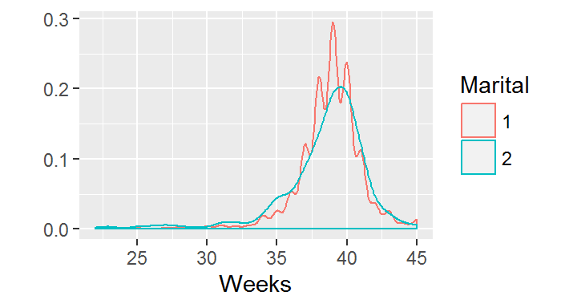

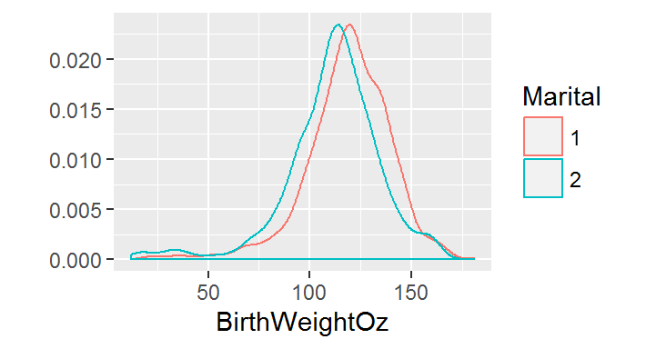

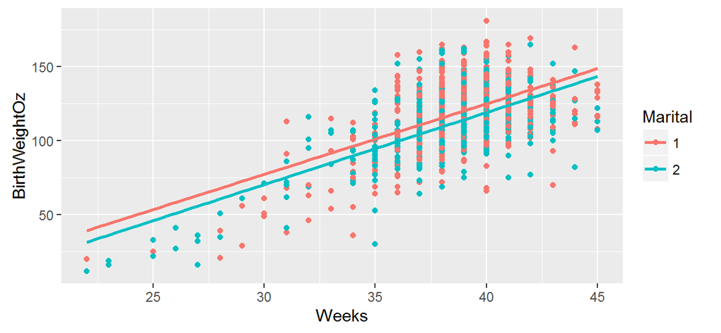

|  | Estimate | Std. Error | t value | Pr(>\|t\|) |
| --- | --- | --- | --- | --- |
| (Intercept) | -61.35 | 7.12 | -8.61 | 0 |
| Weeks | 4.81 | 0.18 | 26.96 | 0 |
| Marital | -6.01 | 1.00 | -6.03 | 0 |

From this linear model fit, we can see that for an increase of 1 week of gestation, we would expect a newborn to weigh, on average, 4.8 Oz more. Additionally, the marital coefficient tells us that, on average, non-married mothers birth children that weigh 6 Oz less than married mothers. An important statistic to pay attention to in a linear regression model is the adjusted R-squared value. This linear model was fit with an $R^2_{adj}$ value of 0.3581.

### Evaluation of Linear Regression Model

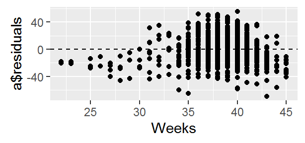

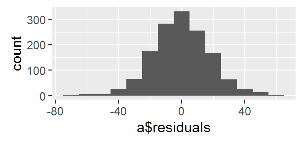

The above plots are useful for checking the conditions for linear regression models. From the right plot, we can see that there appears to be a normal distribution of residuals. The left plot gives us an indication that this relationship may not be linear, there appears to be a slight curve in the residuals plot. This could be due to missing data, as both the residual plot and the scatterplot from the beginning show us that there is a large amount of data collected on births involving 35 or more weeks of gestation, but not much data on lower weeks. If we had more data, the model would be less influenced by high-leverage points on both the lower end and higher end of the spectrum.

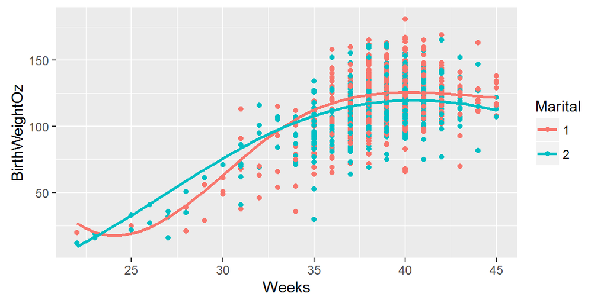

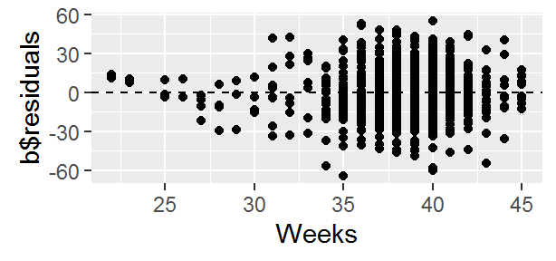

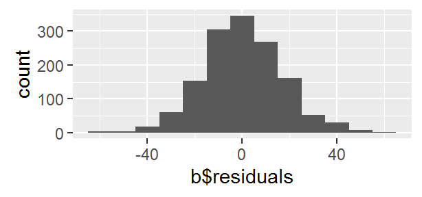

## Martial Status, Child Weight & Multiple Births (Plural)

For this segment, we are looking at the relationship between marital the weight of the child and if there was multiple births. Like with the other segements, we are using the marital status of the mother to see if there is any relationship between them.

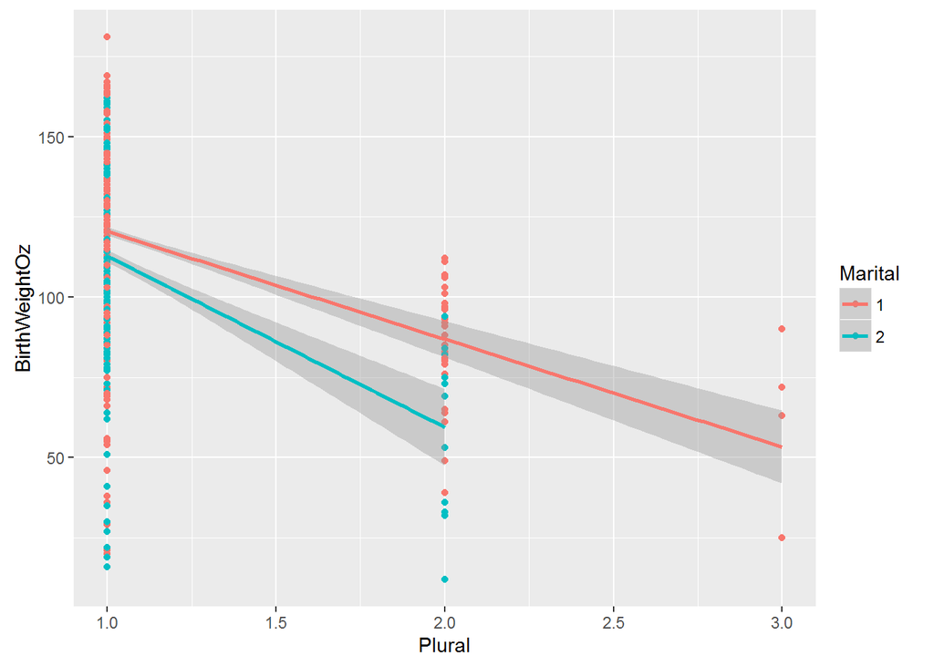

```
##   1   2
## 961 499
```

Looking at the graph from above, we can see that there is a trend with BirthWeightOz that is being affected by Marital status of the mother and multiple births. By having a linear model, we can visualize the trend of the data which happens to be a negative trend with the married mother having a higher average birth weight than a single mother. We also note that being a married mother, the chances of having multiple children during a single birth is higher than a single mother they are more likely to have atleast one child. There could be some explaination for this where the single mother thought that she could not be able to provide for multiple children and chose not to keep them.

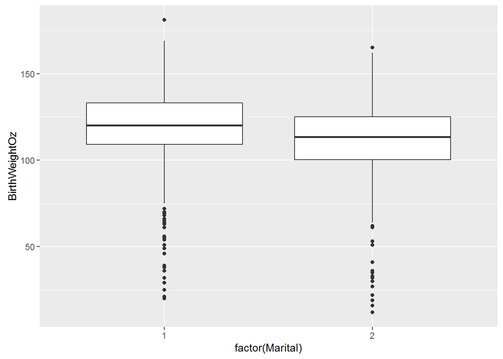

```r
qplot(factor(Marital), BirthWeightOz, data = NCbirths1, geom = "boxplot")
```

```r
tapply(NCbirths1$BirthWeightOz, NCbirths1$Marital, FUN = mean)
```

```
##        1        2
## 119.1040 111.3827
```

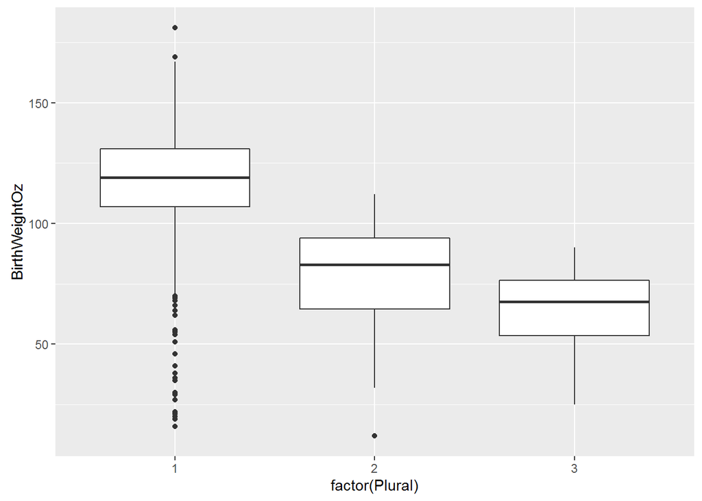

```r
qplot(factor(Plural), BirthWeightOz, data = NCbirths1, geom = "boxplot")
```

```r
tapply(NCbirths1$BirthWeightOz, NCbirths1$Plural, FUN = mean)
```

```
##         1         2         3
## 117.84728  76.90698  62.50000
```

Looking at the box and whisker plots from above, we can see the relationship between the weight of the child at birth and the marital status of the mother. This data was inline with our third hypothesis where being married would have a positive affect on the average weight of the child at birth. Looking at the initial box plot we can see that the average weight of the child is 119.1oz for married mothers and 111.38oz for single mothers. We can also see from the second plot where with each subsequent child, the average weight of the children are much lower. Looking at the average weight of each children for multiple births, we can see a significant drop in average weight from 117.85oz for single children to 76.91oz for twins and 62.5oz for triples. There could be multiple explanations for why this is the case from our data. One could argue that we do not have enough data due to the vast majority of births end in a single child where twins are rare and having triplets are even rarer. One can also believe that with each extra child during the same birth, the mother may not have eaten enough nutrients for each baby.

### Regression Model

```r
birthWeight = lm(BirthWeightOz ~ Plural + Marital, data = NCbirths1)
summary(birthWeight)
```

[output not shown]

From looking at the summary of the birthWeight, we would expect having multiple births will reduce the BirthWeightOz of the baby if all other variables stay constant. It is also important to note that the fit of the linear model which is given by the r-square value which is .1457.

## Marital Status, Age of Mother, and Weight Gained

This section of the analysis explores the relationship between the age of the subject and how much weight they gained after the pregnancy. Marital status is once again used as a categorical variable to see what differences there may be between married and unmarried subjects.

First, we look at a simple plot of all the observations, excluding cases with missing data:

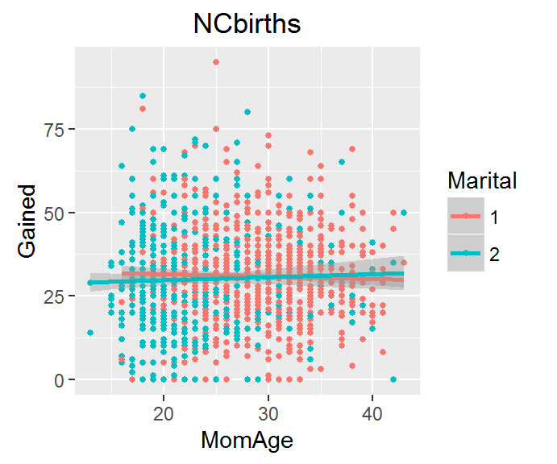

Compared to our original hypothesis of this relation, our inital plot shows little to no correlation between the two variables, with or without the categorical variable of marital status involved. However, when looking at the plots without any regression lines, a majority of observations that are unmarried occur roughly before the median of the age variable (27 years old).

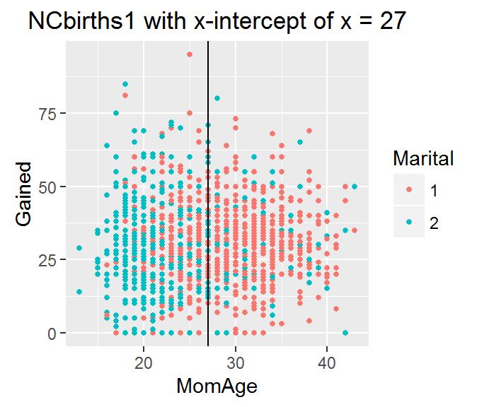

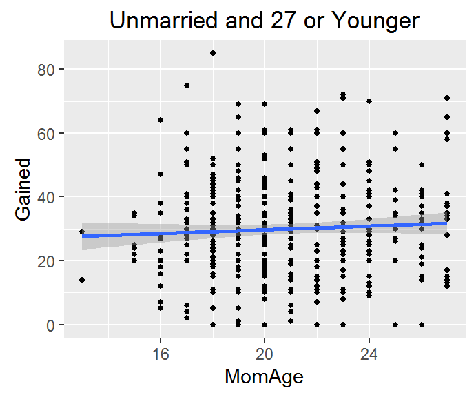

It appears that there could be a stronger relationship between age and weight gained if the dataset is simplified to just unmarried cases who are 27 or younger. To test this theory, we can check a comparison of the p-values of the age variable and R-squared values from the first plot to the second.

| **Dataset** | **p-value** | **R-squared** |
| --- | --- | --- |
| NCbirths1 | 0.249 | 0.0019 |
| NCbirths2 | 0.258 | 0.0032 |

- NCbirths1 contains all observations that have no missing data
- NCbirths2 contains all observations of NCbirths1 that are unmarriend and 27 or younger

After analysis, the new dataset has an increased p-value and is still above 0.05, so it tells us that age still has no statistical significance in relation to weight gained. However, the R-squared value did increase, albeit by an minimal amount. Perhaps this could lead to a greater relationship if the dataset contained more observations. But for now, with this dataset, it is evident that there was not strong enough of a relationship between age and weight gained to show a statistical significance between the two. This also goes against what our initial hypothesis stated, so we conclude that the original hypothesis was indeed false.

One last thing we can take away from the initial plot:

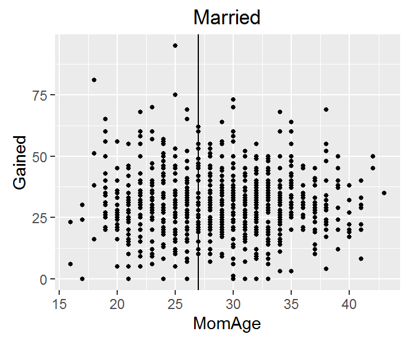

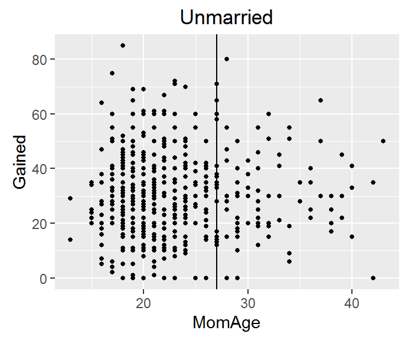